# Assignment 6A- Google Studio HOA & R Programming

Chi Wa Lau

## Programming exercise

### 1) Read the dataset generated from Google Analytics Custom Report

Here we specify the sheet to read from (Dataset1)

```r
library(dplyr, warn.conflicts = FALSE)
library(readxl)
library(tidyr)

df <- read_excel('Social Media Revenue.xlsx', 'Dataset1')
df <- df %>%
  rename(social_media = 'Social Network') %>%
  rename_all(tolower) %>%
  drop_na()
```

```r
# check the structure of the dataframe
df
```

| social_media | transactions | users | revenue | sessions |
| --- | --- | --- | --- | --- |
| (not set) | 1177 | 581446 | 66131.82 | 812009 |
| Facebook | 2 | 2345 | 217.00 | 2702 |
| Twitter | 2 | 3244 | 56.50 | 3614 |
| YouTube | 2 | 19679 | 91.20 | 21028 |
| Google Groups | 1 | 1070 | 74.40 | 1255 |
| Blogger | 0 | 58 | 0.00 | 74 |
| Google+ | 0 | 177 | 0.00 | 179 |
| Hacker News | 0 | 31 | 0.00 | 31 |
| LinkedIn | 0 | 226 | 0.00 | 249 |
| Pinterest | 0 | 96 | 0.00 | 108 |

[output cut: 5 more lines]

```r
# drop (not set)
df = df[-1,]
```

### 2) Perform data translations:

- add these columns. (hint: use mutate) Observe values are percentrages!

  **session_share** = sessions / sum(sessions),  
  **sales_share** = transactions / sum(transactions),  
  **revenue_share** = revenue / sum (revenue)
- Rename transcations to sales
- Then sort by **session_share** in descending order.

#### Add columns

```r
df <- mutate(df, session_share = sessions / sum(sessions))
df <- mutate(df, sales_share = transactions / sum(transactions))
df <- mutate(df, revenue_share = revenue / sum (revenue))
```

#### Rename transaction to sales

```r
colnames(df)[2] <- "sales"
```

#### Sort by **session_share** in descending order.

```r
df<- df %>%
  arrange(desc(df$session_share))
df
```

| social_media | sales | users | revenue | sessions | session_share | sales_share | revenue_share |
| --- | --- | --- | --- | --- | --- | --- | --- |
| YouTube | 2 | 19679 | 91.2 | 21028 | 0.6811129466 | 0.2857143 | 0.2076976 |
| Twitter | 2 | 3244 | 56.5 | 3614 | 0.1170602144 | 0.2857143 | 0.1286723 |
| Facebook | 2 | 2345 | 217.0 | 2702 | 0.0875198393 | 0.2857143 | 0.4941927 |
| Google Groups | 1 | 1070 | 74.4 | 1255 | 0.0406504065 | 0.1428571 | 0.1694375 |
| reddit | 0 | 644 | 0.0 | 668 | 0.0216370291 | 0.0000000 | 0.0000000 |
| Quora | 0 | 542 | 0.0 | 560 | 0.0181388268 | 0.0000000 | 0.0000000 |
| wikiHow | 0 | 291 | 0.0 | 318 | 0.0103002624 | 0.0000000 | 0.0000000 |
| LinkedIn | 0 | 226 | 0.0 | 249 | 0.0080652998 | 0.0000000 | 0.0000000 |
| Google+ | 0 | 177 | 0.0 | 179 | 0.0057979464 | 0.0000000 | 0.0000000 |
| Pinterest | 0 | 96 | 0.0 | 108 | 0.0034982023 | 0.0000000 | 0.0000000 |

[output cut: 4 more lines]

### 3) Show the structure, contents and summary of the transformed data frame.

```r
# show the structure
str(df)
```

```
## tibble [14 × 8] (S3: tbl_df/tbl/data.frame)
##  $ social_media : chr [1:14] "YouTube" "Twitter" "Facebook" "Google Groups" ...
##  $ sales        : num [1:14] 2 2 2 1 0 0 0 0 0 0 ...
##  $ users        : num [1:14] 19679 3244 2345 1070 644 ...
##  $ revenue      : num [1:14] 91.2 56.5 217 74.4 0 0 0 0 0 0 ...
##  $ sessions     : num [1:14] 21028 3614 2702 1255 668 ...
##  $ session_share: num [1:14] 0.6811 0.1171 0.0875 0.0407 0.0216 ...
##  $ sales_share  : num [1:14] 0.286 0.286 0.286 0.143 0 ...
##  $ revenue_share: num [1:14] 0.208 0.129 0.494 0.169 0 ...
```

#### Show the content

```r
# top 6
head(df)
```

| social_media | sales | users | revenue | sessions | session_share | sales_share | revenue_share |
| --- | --- | --- | --- | --- | --- | --- | --- |
| YouTube | 2 | 19679 | 91.2 | 21028 | 0.68111295 | 0.2857143 | 0.2076976 |
| Twitter | 2 | 3244 | 56.5 | 3614 | 0.11706021 | 0.2857143 | 0.1286723 |
| Facebook | 2 | 2345 | 217.0 | 2702 | 0.08751984 | 0.2857143 | 0.4941927 |
| Google Groups | 1 | 1070 | 74.4 | 1255 | 0.04065041 | 0.1428571 | 0.1694375 |
| reddit | 0 | 644 | 0.0 | 668 | 0.02163703 | 0.0000000 | 0.0000000 |
| Quora | 0 | 542 | 0.0 | 560 | 0.01813883 | 0.0000000 | 0.0000000 |

7 sales were made in four social media plaforms: YouTube, Twitter, Facebook, and Google Groups.

```r
# bottom 6
tail(df)
```

| social_media | sales | users | revenue | sessions | session_share | sales_share | revenue_share |
| --- | --- | --- | --- | --- | --- | --- | --- |
| Google+ | 0 | 177 | 0 | 179 | 0.0057979464 | 0 | 0 |
| Pinterest | 0 | 96 | 0 | 108 | 0.0034982023 | 0 | 0 |
| VKontakte | 0 | 57 | 0 | 75 | 0.0024293072 | 0 | 0 |
| Blogger | 0 | 58 | 0 | 74 | 0.0023969164 | 0 | 0 |
| Hacker News | 0 | 31 | 0 | 31 | 0.0010041136 | 0 | 0 |
| Pocket | 0 | 10 | 0 | 12 | 0.0003886891 | 0 | 0 |

#### Show the summary

```r
summary(df)
```

```
##  social_media           sales          users            revenue
##  Length:14          Min.   :0.00   Min.   :   10.0   Min.   :  0.00
##  Class :character   1st Qu.:0.00   1st Qu.:   67.5   1st Qu.:  0.00
##  Mode  :character   Median :0.00   Median :  258.5   Median :  0.00
##                     Mean   :0.50   Mean   : 2033.6   Mean   : 31.36
##                     3rd Qu.:0.75   3rd Qu.:  963.5   3rd Qu.: 42.38
##                     Max.   :2.00   Max.   :19679.0   Max.   :217.00
##     sessions        session_share        sales_share      revenue_share
##  Min.   :   12.00   Min.   :0.0003887   Min.   :0.00000   Min.   :0.00000
##  1st Qu.:   83.25   1st Qu.:0.0026965   1st Qu.:0.00000   1st Qu.:0.00000
##  Median :  283.50   Median :0.0091828   Median :0.00000   Median :0.00000
##  Mean   : 2205.21   Mean   :0.0714286   Mean   :0.07143   Mean   :0.07143
##  3rd Qu.: 1108.25   3rd Qu.:0.0358971   3rd Qu.:0.10714   3rd Qu.:0.09650
##  Max.   :21028.00   Max.   :0.6811129   Max.   :0.28571   Max.   :0.49419
```

### 4) Plot session_share vs sales_share by social media

This plot shows the relationship between sessions vs sales (as a percentage of total) for each social media, even those which did not produce any sales. That is, do not perform any filtering.

Describe insights gained from the visualization.

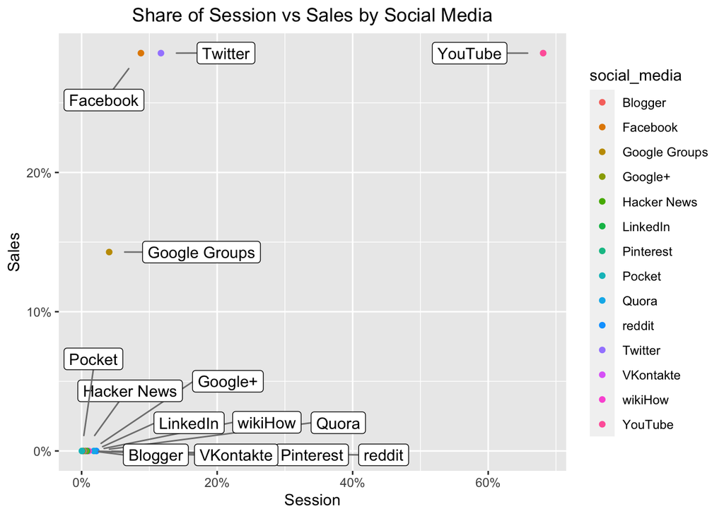

```r
# plot graph
library(ggplot2)
library(ggrepel)
library(scales)

ggplot(df, aes(x=session_share, y=sales_share)) +
  geom_point(aes(color=social_media)) +
  scale_x_continuous(labels=percent) +
  scale_y_continuous(labels=percent) +
  geom_label_repel(aes(label=social_media),
                   point.padding = unit(1.5, 'lines'),
                   segment.color = "grey50") +
  ggtitle("Share of Session vs Sales by Social Media") +
  xlab("Session") +
  ylab("Sales") +
  theme(plot.title = element_text(hjust = 0.5))
```

### 5) Create the same plot above, but this time, filter the data set to only show observations with **sales > 0**.

```r
# dataframe with sales > 0
df_with_sales <-df[!(df$sales==0),]
```

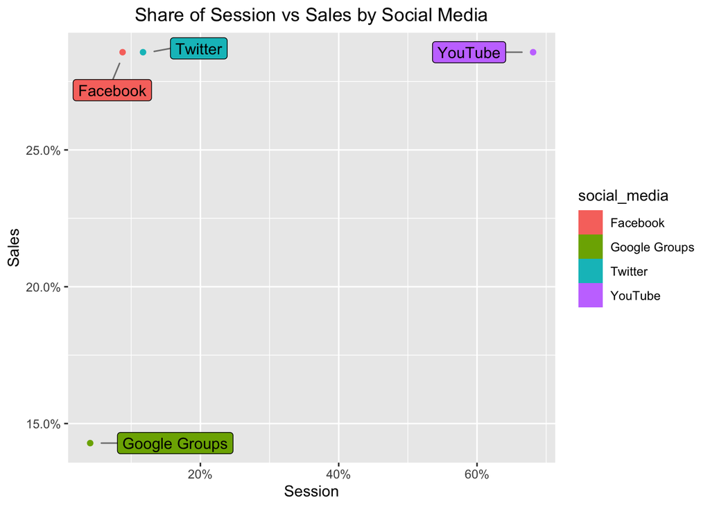

```r
# plot graph
ggplot(df_with_sales, aes(x=session_share, y=sales_share)) +
  geom_point(aes(color=social_media)) +
  scale_x_continuous(labels=percent) +
  scale_y_continuous(labels=percent) +
  geom_label_repel(aes(label=factor(social_media),
                       fill=social_media,),
                   point.padding = unit(1.1, 'lines'),
                   segment.color = "grey50") +
  guides(fill = guide_legend(override.aes = aes(label = ""))) +
  ggtitle("Share of Session vs Sales by Social Media") +
  xlab("Session") +
  ylab("Sales") +
  theme(plot.title = element_text(hjust = 0.5))
```

#### Describe insights from the visualization. How does this report compare to the GA report?

- The line graph in the GA report failed to tell the importance relationship between social media, sessions, and revenue.
- This RStudio graph provides better visualization to tell the relationship of them. With the removal of zero sales data. The graph is better in showing relevant data point that the read will concerns - sales.

### 6) Create another visualizsation of your choice for key metrics, such as **conversion rate**. Consider session versus user for determining conversion rate.

**Background**: In GA, users are the number of unique visitors to a site. Someone visiting a site 10 times on the same device or browser is still counted as one user. GA counts these repeat customers as Returning Users. However, if a user visits a site, deletes their browser cookies, and returns afterwards, they are now counted as New User.

Sessions in GA are in the total number of visits to a site, both new and repeat visits. Sessions should be the same or higher than users.

Since “users” is the unique number, I will use it to calculate the conversion rate.

users conversion rate = (sales / users)*100

```r
# add column for user conversion rate
df_conver <- mutate(df_with_sales, user_conver = (sales/users)*100)
# round up user conversion rate
df_conver$user_conver <- format(round(df_conver$user_conver, 3), nsmall = 3)
df_conver
```

| social_media | sales | users | revenue | sessions | session_share | sales_share | revenue_share | user_conver |
| --- | --- | --- | --- | --- | --- | --- | --- | --- |
| YouTube | 2 | 19679 | 91.2 | 21028 | 0.68111295 | 0.2857143 | 0.2076976 | 0.010 |
| Twitter | 2 | 3244 | 56.5 | 3614 | 0.11706021 | 0.2857143 | 0.1286723 | 0.062 |
| Facebook | 2 | 2345 | 217.0 | 2702 | 0.08751984 | 0.2857143 | 0.4941927 | 0.085 |
| Google Groups | 1 | 1070 | 74.4 | 1255 | 0.04065041 | 0.1428571 | 0.1694375 | 0.093 |

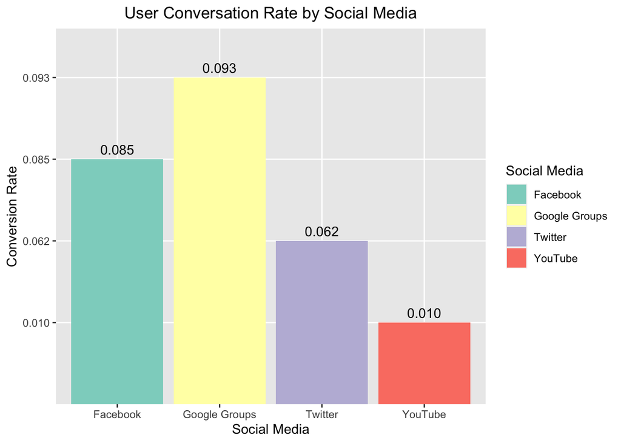

```r
# plot graph
ggplot(df_conver, aes(x=social_media, y=user_conver)) +
  geom_bar(stat = "identity", aes(fill=social_media)) +
  geom_text(aes(x=social_media, y=user_conver, label=user_conver),
            vjust=-0.5) +
  scale_fill_brewer(palette="Set3") +
  ggtitle("User Conversation Rate by Social Media") +
  xlab("Social Media") +
  ylab("Conversion Rate") +
  labs(fill = "Social Media") +
  theme(plot.title = element_text(hjust = 0.5))
```